# Týden 2: datové typy a vektory

## Na zahřátí

#### úkol 1

Vytvořte vektory:

- logický `v1` = (T, F, T),
- celočíselný `v2` = (1, 2, 3) a
- reálný `v3` = (4, 5, 6)

Spojte je dohromady: `v` = (`v1`, `v2`, `v3`).

Je vektor `v` atomický? Pokud ano, jaký má typ?

Jakou má vektor `v` délku?

```r
v1 <- c(TRUE, FALSE, TRUE)
v2 <- c(1L, 2L, 3L)
v3 <- c(4, 5, 6)
v <- c(v1, v2, v3)
v
```

```
[1] 1 0 1 1 2 3 4 5 6
```

```r
typeof(v)
```

```
[1] "double"
```

```r
length(v)
```

```
[1] 9
```

#### úkol 2

Z vektoru `v`

- vyhoďte první a poslední prvek
- vyberte každý 3. prvek
- vyhoďte všechny nuly

```r
v[-c(1, length(v))]
```

```
[1] 0 1 1 2 3 4 5
```

```r
v[seq(from = 3, to = length(v), by = 3)]
```

```
[1] 1 3 6
```

```r
# nebo
v[c(FALSE, FALSE, TRUE)]
```

```
[1] 1 3 6
```

```r
v[v != 0]
```

```
[1] 1 1 1 2 3 4 5 6
```

#### úkol 3

Vytvořte vektor `x` = (1, 1.01, 1.02, …, 4.99, 5) a vektor `y` = `log(x)`. Vykreslete do grafu pomocí `plot(x, y)`.

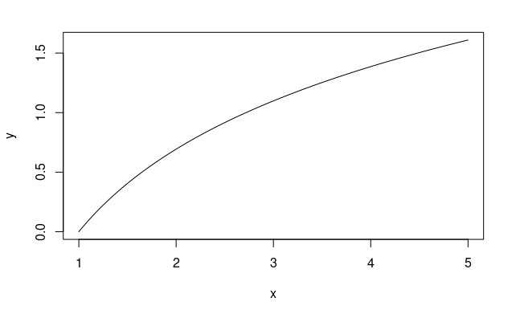

```r
x <- (100:(500)) / 100
# nebo
x <- seq(from = 1, to = 5, by = 0.01)
y <- log(x)
plot(x, y, type = "l")
```

#### úkol 4

Výraz `sample(100, 30)` vrátí 30 náhodných přirozených čísel z intervalu od 1 do 100 bez opakování.

Najděte:

- nejmenší číslo
- druhé nejmenší číslo
- druhé největší číslo

Nápověda: funkce `sort()` čísla setřídí.

```r
cisla <- sample(100, 30)
cisla <- sort(cisla)
cisla[1]  # nejmenší číslo
```

```
[1] 2
```

```r
cisla[2]  # druhé nejmenší číslo
```

```
[1] 3
```

```r
cisla[length(cisla) - 1]  # druhé největší číslo
```

```
[1] 98
```

## Krásy složeného úročení

#### úkol 1

Na účtu máme vklad 1 000 Kč. Úroková sazba je 2 % ročně. Jak se vyvíjí nominální hodnota vkladu v nejbližších 50 letech při složeném úročení? Spočítejte a vykreslete do grafu.

Nápověda: hodnota vkladu $v$ je po $n$ letech při úrokové sazbě $r$ rovna $v (1 + r) ^ n$.

```r
vklad <- 1000
urok <- 2 / 100
let <- 50
roky <- 1:let
hodnota <- vklad * (1 + urok) ^ roky
hodnota
```

```
 [1] 1020.000 1040.400 1061.208 1082.432 1104.081 1126.162 1148.686 1171.659
 [9] 1195.093 1218.994 1243.374 1268.242 1293.607 1319.479 1345.868 1372.786
[17] 1400.241 1428.246 1456.811 1485.947 1515.666 1545.980 1576.899 1608.437
[25] 1640.606 1673.418 1706.886 1741.024 1775.845 1811.362 1847.589 1884.541
[33] 1922.231 1960.676 1999.890 2039.887 2080.685 2122.299 2164.745 2208.040
[41] 2252.200 2297.244 2343.189 2390.053 2437.854 2486.611 2536.344 2587.070
[49] 2638.812 2691.588
```

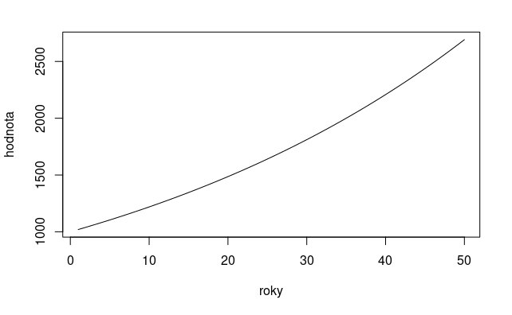

```r
plot(roky, hodnota, type = "l")
```

#### úkol 2

Jaká je hodnota vkladu

- po roce
- po 30 letech
- na konci období
- v každém sudé roce

```r
hodnota[1]
```

```
[1] 1020
```

```r
hodnota[30]
```

```
[1] 1811.362
```

```r
hodnota[length(hodnota)]
```

```
[1] 2691.588
```

```r
hodnota[seq(from = 2, to = length(hodnota), by = 2)]
```

```
 [1] 1040.400 1082.432 1126.162 1171.659 1218.994 1268.242 1319.479 1372.786
 [9] 1428.246 1485.947 1545.980 1608.437 1673.418 1741.024 1811.362 1884.541
[17] 1960.676 2039.887 2122.299 2208.040 2297.244 2390.053 2486.611 2587.070
[25] 2691.588
```

```r
# nebo
hodnota[c(FALSE, TRUE)]
```

```
 [1] 1040.400 1082.432 1126.162 1171.659 1218.994 1268.242 1319.479 1372.786
 [9] 1428.246 1485.947 1545.980 1608.437 1673.418 1741.024 1811.362 1884.541
[17] 1960.676 2039.887 2122.299 2208.040 2297.244 2390.053 2486.611 2587.070
[25] 2691.588
```

#### úkol 3

Stejné zadání jako úkol 1, ale úrok je náhodný z $U(0, 2r)$, kde $r$ je úroková sazba uvažovaná výše.

Nápověda:

- Funkce `runif(n, min, max)` vygeneruje atomický vektor $n$ náhodných čísel z rovnoměrného spojitého rozdělení $U($`min`,`max`$)$.
- Funkce `cumprod(x)` spočítá kumulativní násobek prvků vektoru `x`, tj. pro vektor $(1, 2, 3)$ vrátí vektor $(1,\quad 1 \times 2,\quad 1 \times 2 \times 3) = (1, 2, 6)$.
- Funkce `lines(x, y, col)` umožní do grafu přidat novou čáru s barvou `col` (např. “red”).

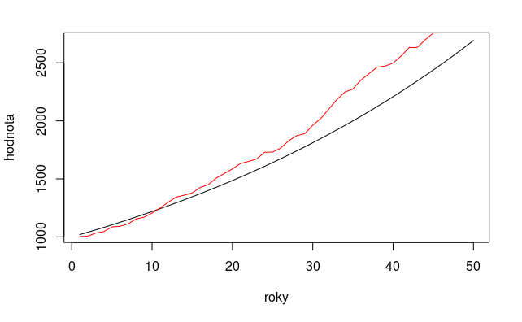

```r
uroky <- runif(let, min = 0, max = 2 * urok)
hodnota2 <- vklad * cumprod(1 + uroky)
plot(roky, hodnota, type = "l")
lines(roky, hodnota2, col = "red")
```

#### úkol 4

O kolik procent se liší hodnota vkladu mezi pevným a kolísajícím úrokem? Vykreslete do grafu.

Domluva: základ pro procenta bude hodnota vkladu při pevném úročení.

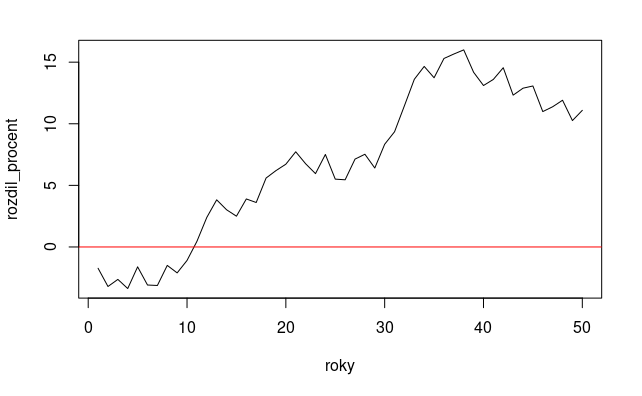

```r
rozdil <- hodnota2 - hodnota
rozdil_procent <- (rozdil / hodnota) * 100
plot(roky, rozdil_procent, type = "l", ylim = range(c(0, rozdil_procent)))
abline(h = 0, col = "red")
```

#### úkol 5

Zjistěte, kdy bude hodnota vkladu (při pevné sazbě) aspoň dvojnásobná, tj. vyšší než 2 000? Kdy se to stane poprvé, tj. jak dlouho trvá, než se vklad zdvojnásobí? Jak dobře funguje “pravidlo 72”?

Nápověda: Pravidlo 72 říká: “Doba, za kterou se vklad zdvojnásobí, je 72 děleno úroková sazba v procentech.”

```r
dost <- hodnota >= 2 * vklad
(roky)[dost]  # roky, kdy je vklad dvojnásobný, nebo více
```

```
 [1] 36 37 38 39 40 41 42 43 44 45 46 47 48 49 50
```

```r
(roky)[dost][1]  # rok, kdy se to stane poprvé
```

```
[1] 36
```

```r
72 / (urok * 100)
```

```
[1] 36
```

#### úkol 6

Změňte úrokovou sazbu a podívejte se, jak se změní výsledky. (Kód by měl být napsaný tak, aby bylo možné jakoukoli konstantu změnit jen na jednom místě!)

## Růst hospodářství

Soubor “exdata02.RData” obsahuje dva vektory: `hdp_bc` je vektor ročních hodnot HDP v mil. Kč v běžných cenách od roku 1990 do 2016; `hdp_sc` je vektor ročního hodnot HDP v mil. Kč v cenách roku 2010 za stejné období. Zdroj dat je ČSÚ. Vektor `cas` obsahuje odpovídající roky.

Data načte pomocí funkce `load("exdata02.RData")`.

```r
load("exdata02.RData")
```

#### úkol 1

Spočítejte hodnotu deflátoru cen a vykreslete jej do grafu.

Nápověda: deflátor $P_t = Y_t / y_t \times 100$, kde $Y_t$ je HDP v běžných cenách a $y_t$ je HDP ve stálých cenách. (V základním roce 2010 by měla být hodnota deflátoru 100.)

```r
deflator <- hdp_bc / hdp_sc * 100
plot(cas, deflator, type = "l")
abline(h = 100, lty = 3)
```

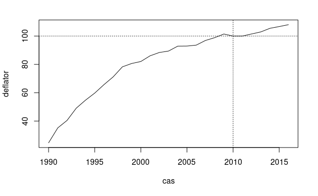

```r
abline(v = 2010, lty = 3)
```

#### úkol 2

Spočítejte roční tempa růstu nominálního HDP, reálného HDP a roční míru inflace a vykreslete je do grafu.

Nápověda: růst i inflace jsou tempa růstu veličiny. Tempo růstu veličiny $y_t$ v čase $t$ spočítáme jako

$$(y_t / y_{t-1}) - 1$$

a můžeme je případně vynásobit 100. (BTW, proč je v grafu vynechán první rok?)

```r
rust_realny <- (hdp_sc[-1] / hdp_sc[-length(hdp_sc)]) - 1
rust_nominalni <- (hdp_bc[-1] / hdp_bc[-length(hdp_bc)]) - 1
inflace <- (deflator[-1] / deflator[-length(deflator)]) - 1
plot(cas[-1], rust_nominalni, type = "l",
     ylim = range(c(rust_realny, rust_nominalni, inflace)))
lines(cas[-1], rust_realny, col = "blue")
```

```r
lines(cas[-1], inflace, col = "red")
abline(h = 0, lty = 3)
```

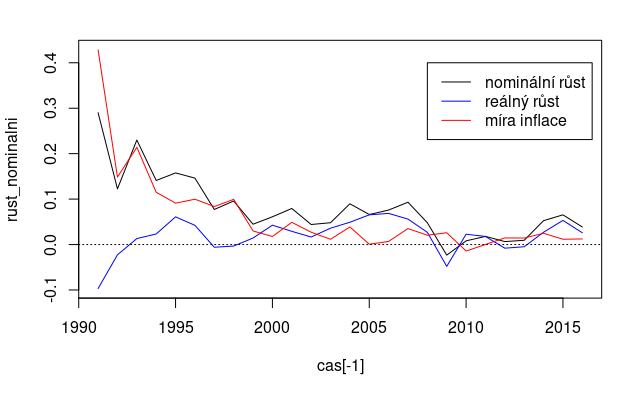

```r
legend(2008, 0.4,
       col = c("black", "blue", "red"),
       legend = c("nominální růst", "reálný růst", "míra inflace"),
       lty = 1)
```

## Elasticita

Máme dva vektory: vektor cen $p = (100, 90, 80, 70, 60, 50)$ Kč a vektor prodaných množství $q = (30, 60, 90, 120, 200, 210)$ tisíc kusů.

#### úkol 1

Spočítejte tržby při každé ceně a vykreslete je do grafu. (Tržby jsou $p_i \times q_i$, kde $p_i$ je cena a $q_i$ je odpovídající množství.)

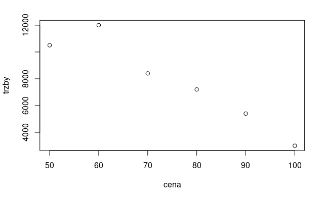

```r
cena <- c(100, 90, 80, 70, 60, 50)
mnozstvi <- c(30, 60, 90, 120, 200, 210)
trzby <- cena * mnozstvi
plot(cena, trzby)
```

#### úkol 2

Spočítejte

- cenovou elasticitu mezi nejvyšší a nejnižší cenou
- cenovou elasticitu mezi každými dvěma sousedními cenami

Nápověda: empirická cenová elasticita se spočítá jako

$$\epsilon = \frac{\frac{q_1 - q_0}{(q_0 + q_1) / 2}}{\frac{p_1 - p_0}{(p_0 + p_1) / 2}},$$

kde $p_i$ je cena a $q_i$ je odpovídající množství.

```r
# po jednotlivých krocích
zmena_ceny <- cena[length(cena)] - cena[1]
zmena_mnozstvi <- mnozstvi[length(mnozstvi)] - mnozstvi[1]
prumerna_cena <- (cena[1] + cena[length(cena)]) / 2
prumerne_mnozstvi <- (mnozstvi[1] + mnozstvi[length(mnozstvi)]) / 2
elasticita_koncova <- (zmena_mnozstvi / prumerne_mnozstvi) / (zmena_ceny / prumerna_cena)
# nebo naráz (dělení dvojkou se pokrátí)
elasticita_koncova <- ((mnozstvi[length(mnozstvi)] - mnozstvi[1]) / (mnozstvi[1] + mnozstvi[length(mnozstvi)])) /
    ((cena[length(cena)] - cena[1]) / (cena[1] + cena[length(cena)]))
# výpis
elasticita_koncova
```

```
[1] -2.25
```

```r
# po jednotlivých krocích
stred_cen <- (cena[-1] + cena[-length(cena)]) / 2
stred_mmozstvi <- (mnozstvi[-1] + mnozstvi[-length(mnozstvi)]) / 2
zmena_ceny <- cena[-1] - cena[-length(cena)]  # nebo diff(cena)
zmena_mnozstvi <- mnozstvi[-1] - mnozstvi[-length(mnozstvi)]  # nebo diff(mnozstvi)
elasticita <- (zmena_mnozstvi / stred_mmozstvi) / (zmena_ceny / stred_cen)
# nebo naráz
elasticita <- ((mnozstvi[-1] - mnozstvi[-length(mnozstvi)]) / (mnozstvi[-1] + mnozstvi[-length(mnozstvi)])) /
    ((cena[-1] - cena[-length(cena)]) / (cena[-1] + cena[-length(cena)]))
elasticita
```

```
[1] -6.3333333 -3.4000000 -2.1428571 -3.2500000 -0.2682927
```

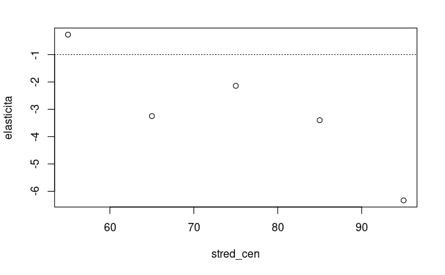

```r
# graf
plot(stred_cen, elasticita)
abline(h = -1, lty = 3)
```